# Example Code - Using Burki Analysis

Paul Johnson

5/16/2020

## Getting Started

The code here is a short analysis that I’ve been working on that looks at Roman Burki’s performances in the last 2 seasons, and compares him with others in the Bundesliga. It primarily focuses on visualizing FB Ref data, particularly StatBomb’s advanced goalkeeping metrics. The code relies on a suite of important packages that you’ll become familiar with, known collectively as the `tidyverse`. The code calls `tidyverse` as its own package, but this is actually a bunch of packages, all of which are incredibly useful, and make up the bulk of what you’re likely to do in R.

### Code Structure

The structure of the code makes more sense when it is placed in a script on its own, as opposed to being part of a markdown file. I’d recommend opening the example .R file and taking a look through that as well, to see how the sections are used in an R script.

Each `# {n}. ----------` is the heading of a section, and each `{# {n.n}. ----------}` is the heading of a subsection. These headings allow you to minimize by section and reduce the amount of code you’re having to look at at one time. This can make it easier to interpret what you’re looking at, as several hundred lines of code can be a little intimidating!

### Packages & Package Management

In order to use the package `pacman`, execute the code `install.packages(pacman)`. Following that, the code in `# 1. PACKAGE MANAGEMENT` will run without error, installing the packages you need to make this code work.

```r
# 1. PACKAGE MANAGEMENT ----------

pacman::p_load(tidyverse, devtools, bbplot,
               scales, ggimage, ggrepel, ggalt,
               ggtext, ggforce, extrafont, concaveman)
```

### Importing Bundesliga Goalkeeping Data

**Make sure to edit the file path.**

```r
# 2. DATA----------

burki <- read_csv("~/Documents/FTW/Burki/buli_keepers_1819_1920.csv")
```

## Cleaning & Preparing the Data - Data Wrangling

This section of code is producing two dataframes with the variables needed to carry out the analysis. The first is simply filtering for the most useful variables, while the second `total_comp` is producing a summary of the variables over the two seasons, either summing or taking the mean average in each case. A filter based on number of minutes played is also applied to `total_comp`, filtering out any players that have played fewer than 17 games (half a season in the Bundesliga).

```r
# 3. WRANGLING ----------

keeper_comp <- burki %>%
  select(Player, Name, Surname, Season, Squad, Born, Mins, GA, GA90, SoTA, SoTA90, PSxG,
         PsxG_90, PsxG_PlusMinus, PsxG_SoT, Launch_Att, Launch_Cmp, Launch_Cmp_Perc,
         Pass_Att, Pass_Launch_Perc, Pass_AvgLen, GK_Att, GK_Launch_Perc, GK_Avg_Len,
         Cross_Att, Cross_Stp, Cross_Stp_Perc, OPA, OPA_90, Sweep_AvgDist)

total_comp <- keeper_comp %>%
  group_by(Surname) %>%
  summarise(Mins = sum(Mins), PsxG_90 = mean(PsxG_90), PsxG_SoT = mean(PsxG_SoT), GA90 = mean(GA90),
            SoTA = sum(SoTA), SoTA90 = mean(SoTA90), PSxG = sum(PSxG), GA = sum(GA),
            PsxG_PlusMinus = sum(PsxG_PlusMinus), Cross_Stp = sum(Cross_Stp), Cross_Stp_Perc = mean(Cross_Stp_Perc)) %>%
  filter(Mins > 1530)
```

## Analysis

The following code gets a little complicated, but it’s not as bad as it seems. There is a consistent logic in the construction of each plot, and that logic is something you’ll gradually pick up over time when using the `tidyverse` packages, particularly `ggplot2`. The code has been annotated in places, to explain some parts of what is going on, and to make it a little easier to follow.

However, I’ve tried to avoid littering it with annotations, because that makes code harder to read in entirety. I’ve also tried to avoid repeating myself, so if a certain section doesn’t make sense, look through the previous plots, and they may contain relevant annotations.

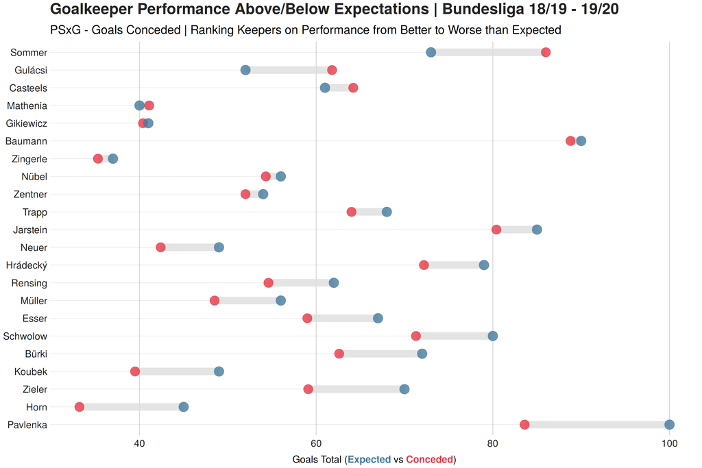

```r
# 4. SHOT STOPPING ANALYSIS ----------

{# 4.1 Dumbell Plots ----------

 # Reshaping the code to be used for a certain plot
  total_comp %>%
    mutate(gap = PSxG - GA) %>%
    arrange(desc(gap)) %>%
    # ggplot(aes(x, y)) is the basis for all figures made in ggplot2 - This is where you'll always start
    ggplot(aes(x = PSxG, xend = GA, y = reorder(Surname, gap))) +
    # geom_() is the type of plot that is being created
    geom_dumbbell(colour = "#dddddd",
                  size = 6.5,
                  colour_x = "#e63946",
                  colour_xend = "#457b9d",
                  alpha = 0.8,
                  dot_guide = TRUE, dot_guide_size = 0.15) +
    # The following code is setting the aesthetic parameters
    bbc_style() +
    labs(title="Goalkeeper Performance Above/Below Expectations | Bundesliga 18/19 - 19/20",
         subtitle="PSxG - Goals Conceded | Ranking Keepers on Performance from Better to Worse than Expected",
         x = "Goals Total (<b style='color:#457B9D'>Expected</b> vs <b style='color:#E63946'>Conceded</b>)", y = NULL) +
    theme(axis.title.x = element_markdown(size = 18),
          axis.text.x = element_markdown(size = 18),
          panel.grid.major.x = element_line(color="#cbcbcb"),
          panel.grid.major.y=element_blank())
}
```

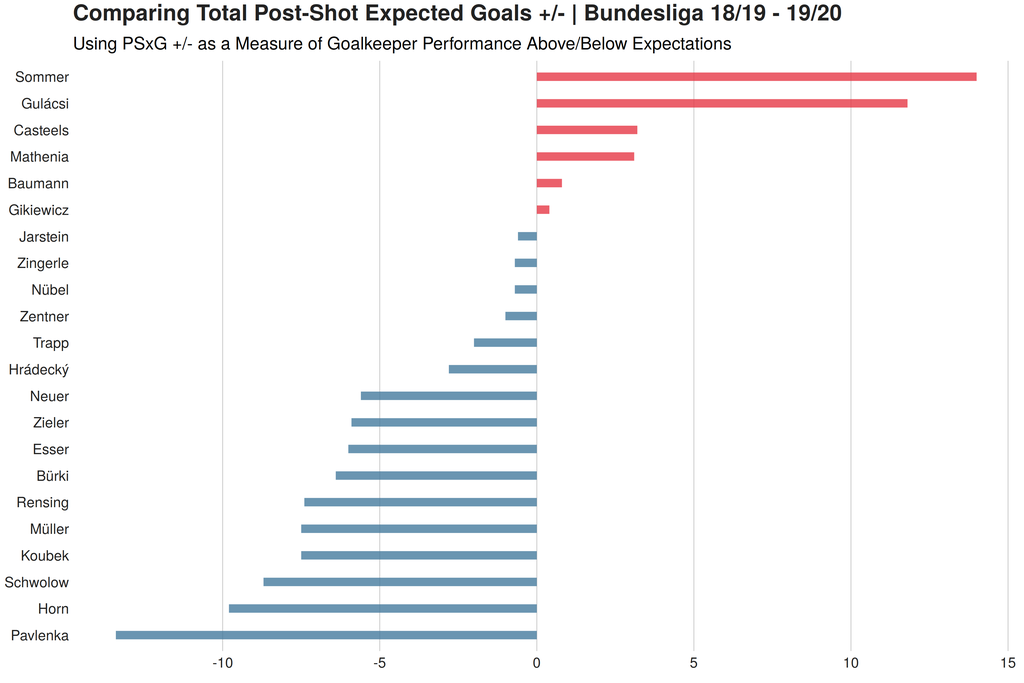

```r
{# 4.2 PSxG +/-

  total_comp %>%
    mutate(comp_color = ifelse(PsxG_PlusMinus > 0, "type1", "type2")) %>%
    ggplot(aes(x = reorder(Surname, PsxG_PlusMinus), y = PsxG_PlusMinus)) +
    geom_segment(aes(x=0, xend=PsxG_PlusMinus, y=reorder(Surname, PsxG_PlusMinus),
                     yend=reorder(Surname, PsxG_PlusMinus), color=comp_color), size=5, alpha=0.8) +
    bbc_style() + theme(legend.position = "none",  panel.grid.major.x = element_line(color="#cbcbcb"),
                        panel.grid.major.y=element_blank()) +
    scale_color_manual(values = c("#e63946", "#457b9d")) +
    labs(title="Comparing Total Post-Shot Expected Goals +/- | Bundesliga 18/19 - 19/20 ",
         subtitle="Using PSxG +/- as a Measure of Goalkeeper Performance Above/Below Expectations")

}
```

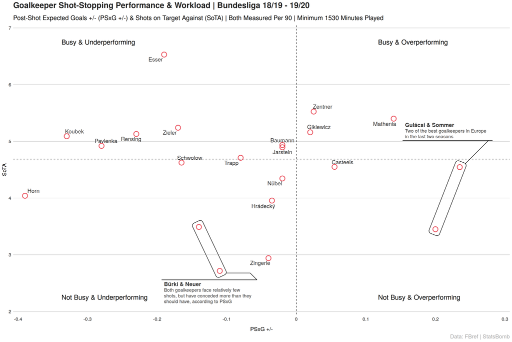

```r
{# 4.3 GK Plots ----------

  # Setting labels for the following plot
  burkineuer_desc <- "Both goalkeepers face relatively few shots, but have conceded more than they should have, according to PSxG"

  gulascisommer_desc <- "Two of the best goalkeepers in Europe in the last two seasons"

  ggplot(total_comp, aes(x = PsxG_90, y = SoTA90)) +
    geom_vline(xintercept = 0, linetype = "dashed") + geom_hline(yintercept = 4.687, linetype =  "dashed") +
    # Annotating the plot with 4 different labels (in each corner)
    annotate("text", x = -0.3375, y = 6.75, hjust = 0, size = 6,
             label = "Busy & Underperforming") +
    annotate("text", x = -0.3375, y = 2.25, hjust = 0, size = 6,
             label = "Not Busy & Underperforming") +
    annotate("text", x = 0.1175, y = 2.25, hjust = 0, size = 6,
             label = "Not Busy & Overperforming") +
    annotate("text", x = 0.1175, y = 6.75, hjust = 0, size = 6,
             label = "Busy & Overperforming") +
    geom_point(aes(),
               shape = 21, size = 5, color = "#e63946", alpha = 0.8, stroke = 1.5) +
    # Player Data
    geom_text_repel(data = total_comp %>%
                      filter(!Surname %in% c("Bürki", "Gulácsi", "Sommer", "Neuer")),
                    aes(label = Surname),
                    min.segment.length = 0.3, seed = 15, size = 5,
                    point.padding = 0.2, segment.alpha = 0, color = "grey20") +
    # Marking the points in the figure that the labels set above (burkineuer_desc and gulascisommer_desc) are referring to
    geom_mark_hull(
      aes(filter = Surname %in% c("Bürki", "Neuer"),
          label = "Bürki & Neuer",
          description = burkineuer_desc),
      expand = unit(5, "mm"), con.cap = unit(0, "mm"),
      label.width = unit(85, 'mm'), label.buffer = unit(0.1, "mm"),
      label.fontsize = c(14, 12), label.colour = "grey20") +
    geom_mark_hull(
      aes(filter = Surname %in% c("Gulácsi", "Sommer"),
          label = "Gulácsi & Sommer",
          description = gulascisommer_desc),
      expand = unit(5, "mm"), con.cap = unit(0, "mm"),
      label.width = unit(80, 'mm'), label.buffer = unit(16, "mm"),
      label.fontsize = c(14, 12), label.colour = "grey20") +
    labs(title = "Goalkeeper Shot-Stopping Performance & Workload | Bundesliga 18/19 - 19/20",
         subtitle = "Post-Shot Expected Goals +/- (PSxG +/-) & Shots on Target Against (SoTA) | Both Measured Per 90 | Minimum 1530 Minutes Played",
         x = "PSxG +/-",
         y = "SoTA",
         caption = "Data: FBref | StatsBomb") +
    # Setting the scales of each axis
    scale_x_continuous(labels = seq(-0.4, 0.3, 0.1),
                       breaks = seq(-0.4, 0.3, 0.1),
                       limits = c(-0.4, 0.3),
                       expand = c(0.01, 0)) +
    scale_y_continuous(labels = seq(2, 7, 1),
                       breaks = seq(2, 7, 1),
                       limits = c(2, 7),
                       expand = c(0.01, 0)) +
    bbc_style() +
    theme(plot.title = element_markdown(size = 20),
          plot.subtitle = element_markdown(size = 16),
          plot.caption = element_text(size = 14, color = "#a8a8a8"),
          axis.title = element_text(size = 14),
          axis.text = element_text(size = 12))

}
```